#### **To: Quian Xu**

#### **From: Jennifer Grosz and Josh Wolfe**

#### **Date: 07/29/2021**

#### **RE: General Mills Competitive Marketplace Analysis**

In this analysis we examine General Mills cereal product and strategy performance relative to our two main competitors: Kelloggs and Post. The data you provided us with consists of the sales records for 15 different cereals across three brands including the use of promotions and advertisements, weekly sales totals, store information, and the sale price. This sales information is important because these brands are our competitors and consumers are likely looking at all three brand’s products simultaneously when making purchasing decisions.

We set out on this analysis with the goal of identifying areas of interest in General Mills’ performance as it pertains to in-store promotions and advertisements in an effort to make data driven business decisions and increase overall product sales. Using this data, we can assess the effectiveness of General Mills’ advertisement and promotion strategies in comparison to our competitors and we’ve come up with some interesting findings to share with you.

| brand | average discount | units sold during in-store promotions |
| --- | --- | --- |
| GENERAL MILLS | $1.06 | 15,963 |
| KELLOGGS | $0.99 | 30,269 |
| POST | $0.95 | 4,657 |

The table above shows the average promotion discount offered by each brand and the units sold during in store promotions. As you can see, General Mills’ promotions offer the largest price discount, yet sell fewer units during in-store promotions than Kelloggs brand. We found this odd and wanted to further investigate what might be driving the higher unit sales for Kelloggs’ products despite General Mill’s better promotion price. Below is a visualization of what we found.

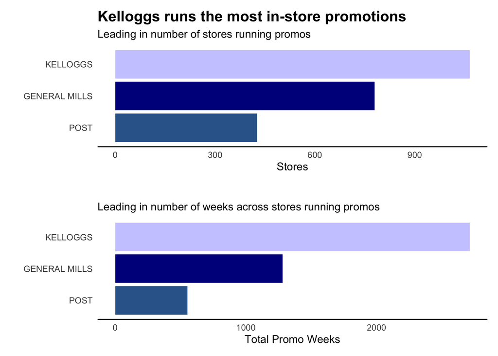

Fig 1

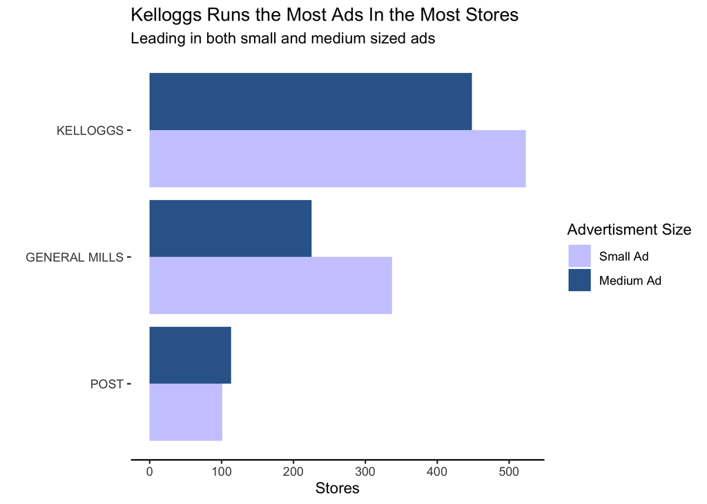

Fig 2

When it comes to in-store advertisements we have found that Kelloggs runs the most overall. Out of both small and medium sized advertisements Kelloggs beats General Mills in placement of both ad sizes in stores by a reliable margin. Kelloggs running more advertisements of all size in both stores and overall count could help explain why Kelloggs also leads in overall sales. It follows that General Mills sits between Kelloggs and Post in both advertisements and overall sale performance.

In conclusion we recommend two courses of action: The first is increasing the number of in-store promotions across either stores or weeks of the year. The second is increasing the amount of small and medium advertisements in stores. General Mill’s pricing is competitive, but the promotional offerings and advertisements are lagging behind Kelloggs.

Please feel free to let us know if there is anything further we can do to assist with your research. We both enjoyed conducting this analysis and would like the opportunity to ask a couple of questions about this data set and share more insights with you if you’re open to hearing them.

In the meantime, please feel free to let us know if you have any questions or would like to discuss any part of this analysis in greater detail. You can reach us at groszj@seattleu.edu or jwolfe@seattleu.edu. We can also send over the Technical Appendix with our complete analysis and the data if you would like more information, just let us know!

Sincerely, Jenni & Josh